# VISUALISASI DATA DENGAN GGPLOT2

Latif Almizan

2025-01-30

## PENGANTAR GGPLOT2

Introduction to ggplot2 ggplot2 is one of the most popular packages for data visualization in the R programming language. This package allows us to create various types of plots easily and flexibly using the concept of Grammar of Graphics.

1. Grammar of Graphics The main concept of ggplot2 is the Grammar of Graphics, which enables the creation of plots by combining layers of visual components. Plots are built step by step by adding various visual elements such as points, lines, or areas.
2. Basic Structure of ggplot2 The basic structure of ggplot2 syntax is as follows:

ggplot(data, aes(x, y)) + geom_type()

data: A data frame that contains the data you want to visualize. aes: Aesthetics that determine the mapping of variables to visual elements. geom_type(): Geom function that specifies the type of plot (e.g., geom_point() for scatter plots, geom_line() for line plots).

3. Aesthetics (aes) Aesthetics are used to determine how variables in the data will be mapped to visual elements:

ggplot(data, aes(x = variable_x, y = variable_y))

These variables can be mapped to the x-axis, y-axis, color, size, and shape.

4. Geoms Geoms are the types of plots used in ggplot2. Some examples of geom functions are:

geom_point(): For scatter plots.

geom_line(): For line plots.

geom_bar(): For bar plots.

5. Basic Example Here is a basic example of creating a scatter plot using ggplot2:

# Load the ggplot2 package

library(ggplot2)

# Create a scatter plot

ggplot(mtcars, aes(x = wt, y = mpg)) + geom_point() + labs(title = “Scatter Plot of Weight vs. MPG”, x = “Weight (1000 lbs)”, y = “Miles per Gallon”)

This example uses the mtcars dataset to create a scatter plot of car weight against miles per gallon (MPG).

6. Plot Customization ggplot2 allows you to customize your plots as needed:

ggplot(mtcars, aes(x = wt, y = mpg)) + geom_point(color = “blue”, size = 3) + labs(title = “Custom Scatter Plot”, x = “Weight (1000 lbs)”, y = “Miles per Gallon”) + theme_minimal()

This example shows how to change the color and size of the points, add titles and labels, and apply a minimal theme.

7. Additional Resources To learn more about ggplot2, here are some resources you can utilize:
- ggplot2 book
- R for Data Science
- ggplot2 documentation ## INTRODUCTION GGPLOT 2 Pengantar ggplot2 ggplot2 adalah paket visualisasi data yang sangat kuat dalam ekosistem R. Paket ini memungkinkan pengguna untuk membuat grafik yang indah dan informatif dengan mudah. Dibangun berdasarkan prinsip Grammar of Graphics, ggplot2 memberikan kerangka kerja yang fleksibel untuk menghasilkan visualisasi data yang mendalam.

1.Konsep Utama Grammar of Graphics: Ini adalah konsep inti di balik ggplot2 yang memungkinkan pembuatan grafik melalui kombinasi lapisan-lapisan komponen visual. Setiap grafik dapat dibangun dari beberapa lapisan yang menggambarkan data dengan cara tertentu.

2.Aesthetics (aes): Aesthetics mendefinisikan bagaimana data dipetakan ke elemen-elemen visual, seperti posisi x dan y, warna, ukuran, dan bentuk. Misalnya:

```
ggplot(data, aes(x = variabel_x, y = variabel_y, color = variabel_warna))
```

Di sini, variabel_x dan variabel_y dipetakan ke sumbu x dan y, sementara variabel_warna dipetakan ke warna elemen grafik.

3.Geoms: Geoms adalah elemen grafis yang digunakan untuk menggambarkan data. Contoh geom termasuk: *geom_point(): Untuk membuat scatter plot.* geom_line(): Untuk membuat line plot. *geom_bar(): Untuk membuat bar plot.

Struktur Dasar ggplot2 Struktur dasar dari sintaks ggplot2 adalah sebagai berikut:

```
ggplot(data, aes(x, y)) + geom_type()
```

*data: Data frame yang berisi data yang ingin divisualisasikan.* aes: Aesthetics yang menentukan pemetaan variabel ke elemen visual. *geom_type(): Fungsi geom yang menentukan jenis grafik (misalnya, geom_point() untuk scatter plot, geom_line() untuk line plot).

Contoh Dasar Berikut adalah contoh dasar pembuatan scatter plot menggunakan ggplot2:

```
# Memuat paket ggplot2
library(ggplot2)
# Membuat scatter plot
ggplot(mtcars, aes(x = wt, y = mpg)) +
  geom_point() +
  labs(title = "Scatter Plot Berat vs. MPG",
       x = "Berat (1000 lbs)",
       y = "Mil per Galon")
```

Contoh ini menggunakan dataset mtcars untuk membuat scatter plot yang memvisualisasikan hubungan antara berat mobil dan konsumsi bahan bakar (MPG).

Kustomisasi Grafik

ggplot2 memungkinkan kustomisasi grafik secara mendalam. Berikut adalah contoh kustomisasi:

```
ggplot(mtcars, aes(x = wt, y = mpg, color = factor(cyl))) +
  geom_point(size = 3) +
  labs(title = "Custom Scatter Plot",
       x = "Weight (1000 lbs)",
       y = "Miles per Gallon",
       color = "Cylinders") +
  theme_minimal()
```

Pada contoh ini, warna titik ditentukan berdasarkan jumlah silinder, ukuran titik diperbesar, dan tema minimal diterapkan.

Layering dalam ggplot2

ggplot2 memungkinkan penambahan lapisan-lapisan tambahan untuk meningkatkan kompleksitas dan detail grafik. Contohnya:

```
ggplot(mtcars, aes(x = wt, y = mpg)) +
  geom_point(aes(color = factor(cyl))) +
  geom_smooth(method = "lm", se = FALSE) +
  labs(title = "Scatter Plot with Regression Line",
       x = "Weight (1000 lbs)",
       y = "Miles per Gallon",
       color = "Cylinders") +
  theme_classic()
```

Pada contoh ini, sebuah garis regresi linear ditambahkan untuk menunjukkan tren data.

Sumber Daya Tambahan

Untuk mempelajari lebih lanjut tentang ggplot2, Anda dapat merujuk pada sumber daya berikut:

*Buku ggplot2* R for Data Science *Dokumentasi ggplot2

## DASAR-DASAR MATERI GGPLOT2

ggplot2 adalah paket visualisasi data yang sangat kuat dan populer dalam bahasa pemrograman R. Paket ini memanfaatkan konsep Grammar of Graphics untuk memudahkan pembuatan grafik yang kompleks dan menarik.

1. Instalasi ggplot2 Sebelum menggunakan ggplot2, Anda perlu menginstalnya terlebih dahulu. Gunakan perintah berikut untuk instalasi:

```
install.packages("ggplot2")
```

Kemudian, muat paketnya dengan:

```
library(ggplot2)
```

2. Struktur Dasar ggplot2 Struktur dasar dari sintaks ggplot2 adalah sebagai berikut:

```
ggplot(data, aes(x, y)) + geom_type()
```

*data: Data frame yang berisi variabel yang ingin divisualisasikan.* aes: Aesthetics yang menentukan pemetaan variabel ke elemen visual. *geom_type(): Fungsi geom yang menentukan jenis grafik, seperti geom_point() untuk scatter plot atau geom_line() untuk line plot.

3.Aesthetics (aes) *Memetakan variabel ke elemen visual (x, y, warna, ukuran).* Contoh: aes(x = variabel_x, y = variabel_y)

4.Geoms *geom_point(): Scatter plot* geom_line(): Line plot *geom_bar(): Bar plot

5.Contoh Dasar ggplot(mtcars, aes(x = wt, y = mpg)) + geom_point() + labs(title = “Scatter Plot Berat vs. MPG”, x = “Berat (1000 lbs)”, y = “Mil per Galon”) 6.Kustomisasi

```
ggplot(mtcars, aes(x = wt, y = mpg)) +
  geom_point(color = "blue", size = 3) +
  labs(title = "Custom Scatter Plot",
       x = "Weight (1000 lbs)",
       y = "Miles per Gallon") +
  theme_minimal()
```

7.Menambahkan Lapisan

```
ggplot(mtcars, aes(x = wt, y = mpg)) +
  geom_point(aes(color = factor(cyl))) +
  geom_smooth(method = "lm", se = FALSE) +
  labs(title = "Scatter Plot with Regression Line",
       x = "Weight (1000 lbs)",
       y = "Miles per Gallon",
       color = "Cylinders") +
  theme_classic()
```

## Read Data

data=gapminder

Kita juga dapat memanggil semua library dalam satu chunk dan kita dapat menggunakannya berulang kali tanpa perlu memanggilnya lagi.

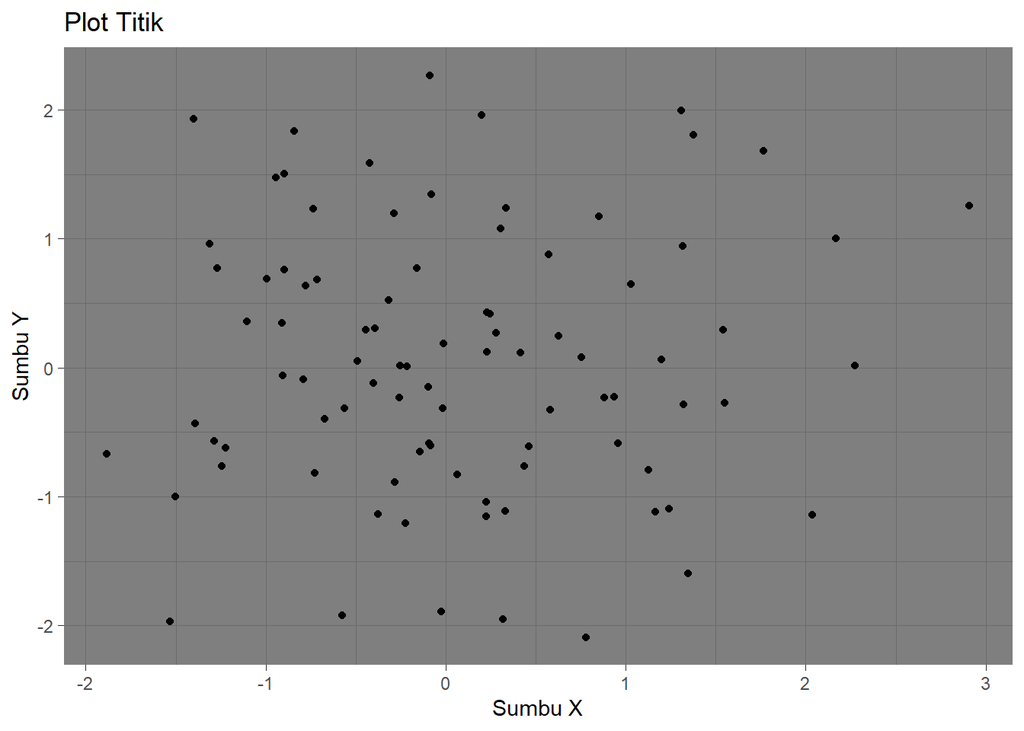

```r
# memanggil library
library(ggplot2)
# membuat data dengan base R
data <- data.frame(x = rnorm(90), y = rnorm(90))
# membuat scotter plot
ggplot(data, aes(x = x, y = y)) +
geom_point() +
labs(title = "Plot Titik", x = "Sumbu X", y = "Sumbu Y") +
theme_dark()
```

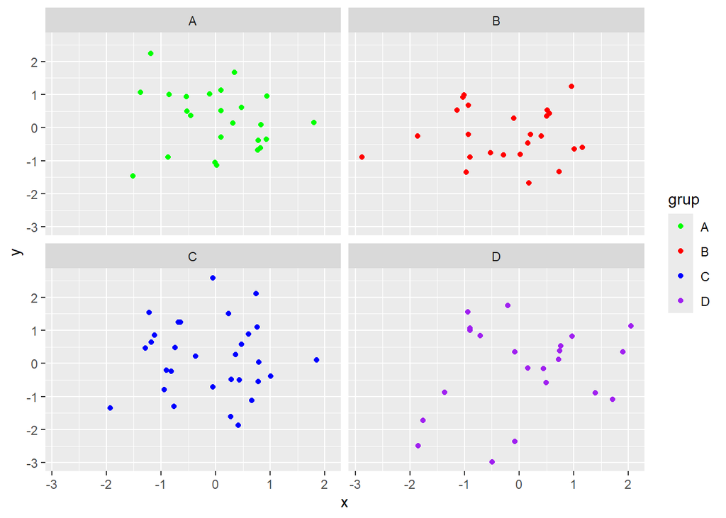

```r
# Membuat data dengan base R
data <- data.frame(
  x = rnorm(100),
  y = rnorm(100),
  grup = sample(c("A", "B", "C", "D"), 100, replace = TRUE)
)

# Membuat scatter plot dengan warna berbeda setiap grupnya
library(ggplot2)

ggplot(data, aes(x = x, y = y, color = grup)) +
  geom_point() +
  facet_wrap(~ grup) +
  scale_color_manual(values = c("A" = "green", "B" = "red", "C" = "blue", "D" = "purple"))
```

Dalam contoh tersebut, fungsi ggplot() digunakan untuk menginisialisasi plot dengan data dan pemetaan estetika (aesthetic mapping) melalui ses). Pemetaan estetika ini menentukan bagaimana variabel data seperti sumbu x dan y akan ditampilkan pada grafik. Fungsi geom point() menambahkan lapisan geometri untuk menggambar titik-titik pada scatter plot, yang merupakan elemen utama dalam visualisasi ini. Fungsi-fungsi ini bekerja bersama secara modular, memungkinkan pengguna untuk membangun plot sesuai kebutuhan secara bertahap.

```r
# Memuat paket readr
library(readr)

# Membaca file CSV
lizard <- read_csv("lizards.csv", show_col_types = FALSE)
```

### Contoh penggunaan ggplot 3

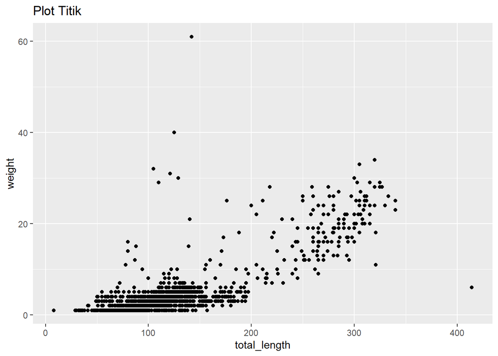

```r
ggplot(lizard, aes(x = total_length , y = weight)) +
geom_point() +
labs(title = "Plot Titik", x = "total_length" , y = "weight" )
```

### Contoh penggunaan ggplot 4

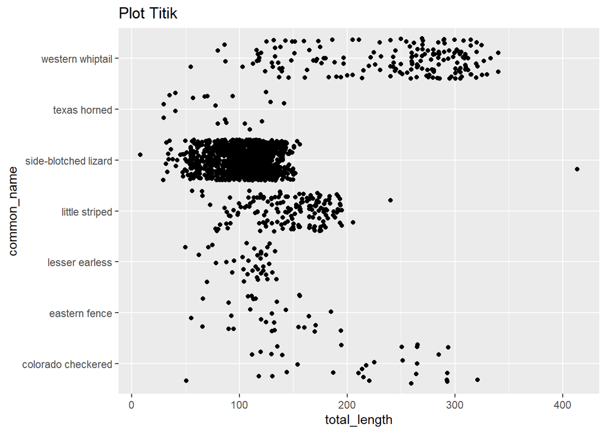

```r
ggplot(lizard, aes(x = total_length , y = common_name)) +
geom_jitter() +
labs(title = "Plot Titik", x = "total_length" , y = "common_name" )
```

### Contoh penggunaan ggplot 5

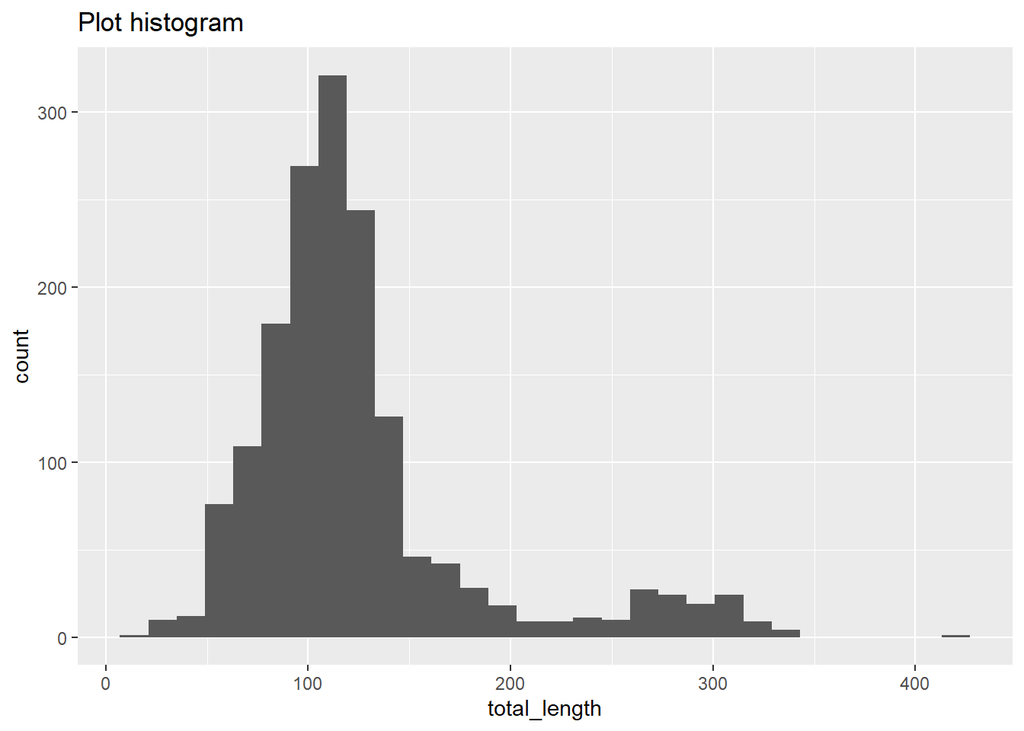

```r
ggplot(lizard, aes(x = total_length)) +
geom_histogram() +
labs(title = "Plot histogram", x = "total_length" )
```

### Contoh penggunaan ggplot 6

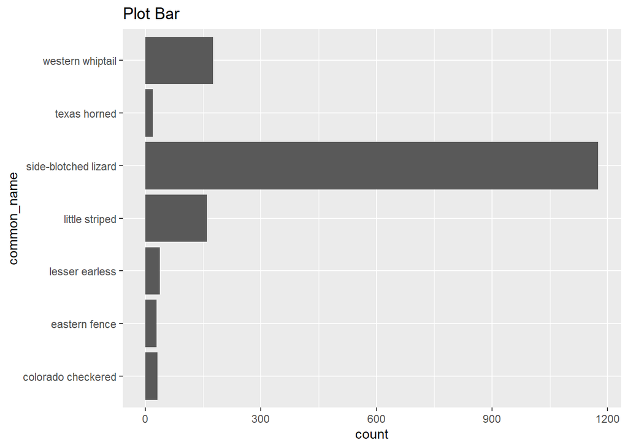

```r
ggplot(lizard, aes( , y = common_name)) +
geom_bar() +
labs(title = "Plot Bar",  , y = "common_name" )
```

### Contoh penggunaan ggplot 7

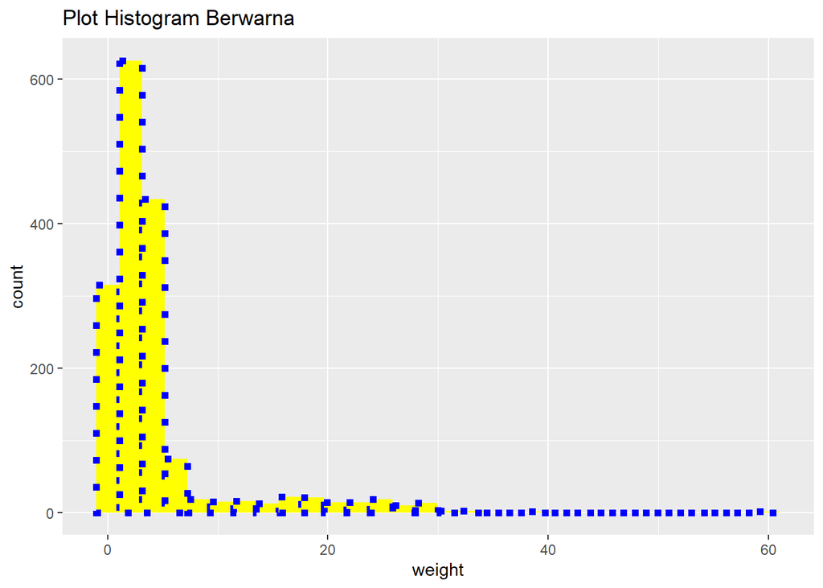

```r
ggplot(lizard, aes(x = weight)) +
geom_histogram(colour = "blue", fill = "yellow", size = 2, linetype = "dotted") +
labs(title = "Plot Histogram Berwarna", x = "weight" )
```

### Contoh penggunaan ggplot 8

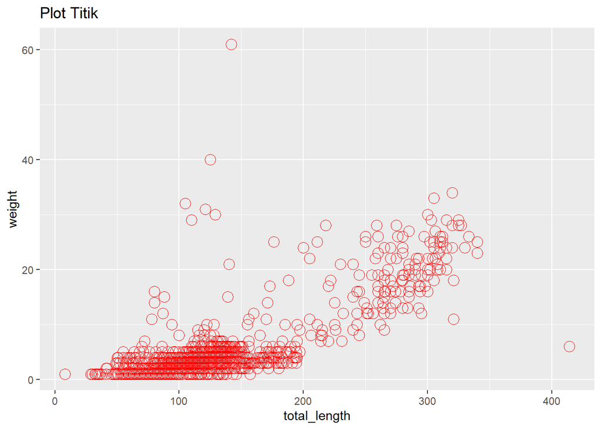

```r
ggplot(lizard, aes(x = total_length , y = weight)) +
geom_point(colour = "red", shape = 21, size = 4) +
labs(title = "Plot Titik", x = "total_length" , y = "weight" )
```

### Contoh penggunaan ggplot 9

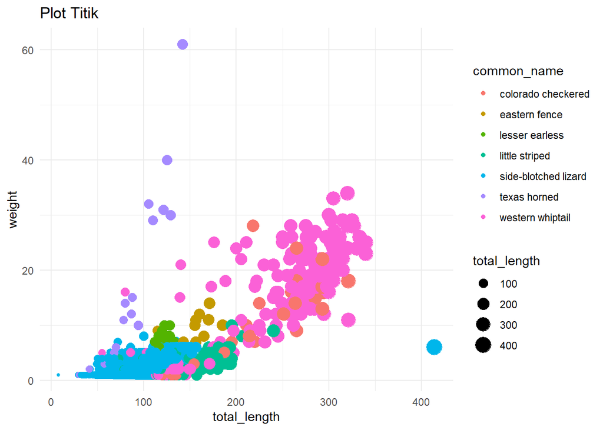

```r
ggplot(lizard, aes(x = total_length, y = weight, color = common_name, size = total_length)) +
  geom_point(shape = 19) +
  labs(title = "Plot Titik", x = "total_length", y = "weight") +
  theme_minimal()
```

```r
library (gapminder)
library (ggplot2)
library (gganimate)
```

```r
library(gapminder)
data=gapminder
data
```

| country | continent | year | lifeExp | pop | gdpPercap |
| --- | --- | --- | --- | --- | --- |
| Afghanistan | Asia | 1952 | 28.80100 | 8425333 | 779.4453 |
| Afghanistan | Asia | 1957 | 30.33200 | 9240934 | 820.8530 |
| Afghanistan | Asia | 1962 | 31.99700 | 10267083 | 853.1007 |
| Afghanistan | Asia | 1967 | 34.02000 | 11537966 | 836.1971 |
| Afghanistan | Asia | 1972 | 36.08800 | 13079460 | 739.9811 |
| Afghanistan | Asia | 1977 | 38.43800 | 14880372 | 786.1134 |
| Afghanistan | Asia | 1982 | 39.85400 | 12881816 | 978.0114 |
| Afghanistan | Asia | 1987 | 40.82200 | 13867957 | 852.3959 |
| Afghanistan | Asia | 1992 | 41.67400 | 16317921 | 649.3414 |
| Afghanistan | Asia | 1997 | 41.76300 | 22227415 | 635.3414 |

[output cut: 1694 more lines]

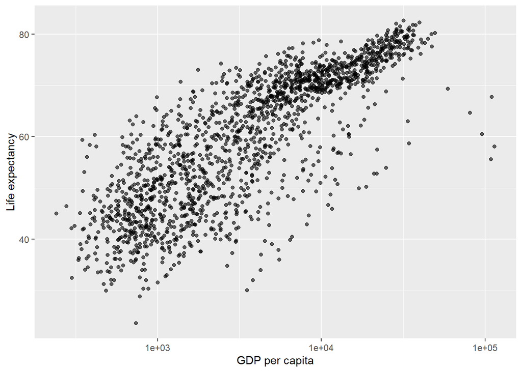

```r
library(gapminder)
library(ggplot2)
gapminder_plot <- ggplot(
  gapminder,
  aes(x = gdpPercap, y=lifeExp)
  ) +
  geom_point(alpha = 0.6) +
  scale_x_log10() +
  labs(x = "GDP per capita", y = "Life expectancy")
gapminder_plot
```

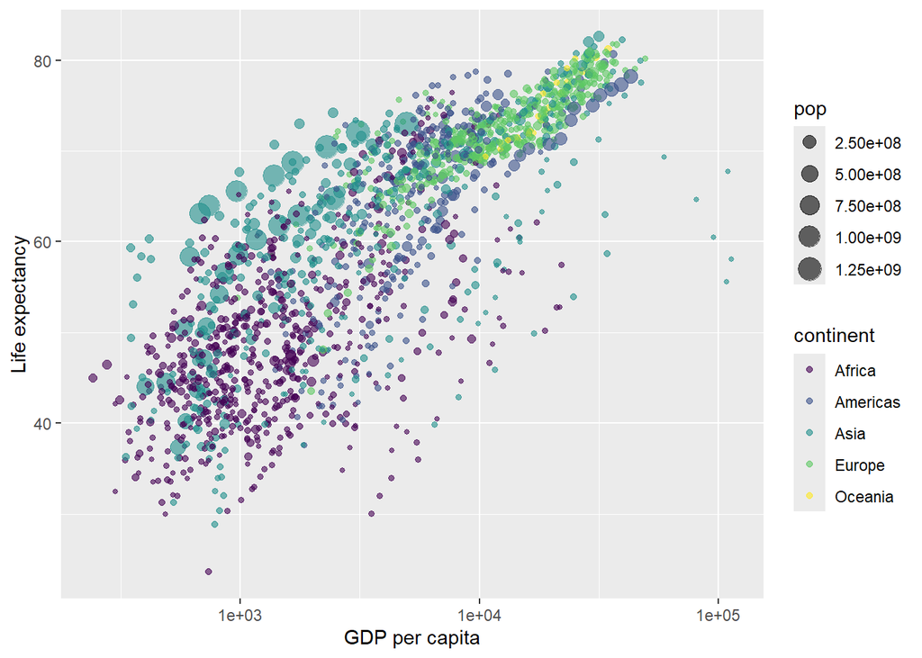

```r
gapminder_plot <- ggplot(
  gapminder,
  aes(x = gdpPercap, y=lifeExp, size = pop, colour = continent)
  ) +
  geom_point(alpha = 0.6) +
  scale_x_log10() +
  scale_color_viridis_d(option = "viridis") +
  labs(x = "GDP per capita", y = "Life expectancy")
gapminder_plot
```

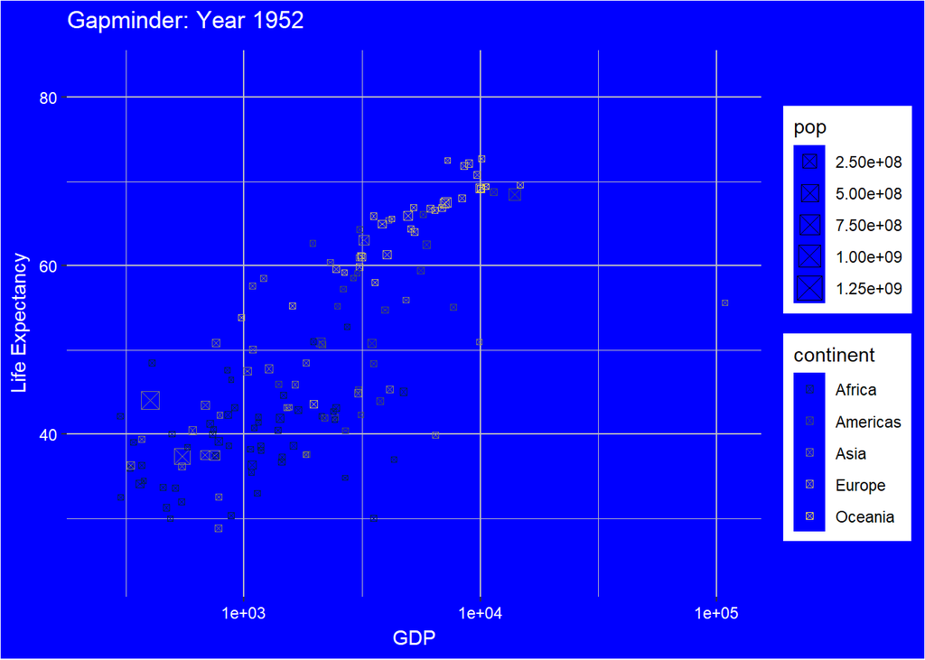

```r
library(ggplot2)
library(gganimate)
library(gifski)

# Sample data, assuming 'data' includes a 'year' variable
gapminder_plot <- ggplot(data, aes(x = gdpPercap, y = lifeExp, colour = continent, size = pop)) +
  geom_point(shape = 7) +
  scale_x_log10() +
  scale_color_viridis_d(option = "cividis") +
  labs(title = "Gapminder", x = "GDP", y = "Life Expectancy") +
  theme(
    panel.background = element_rect(fill = "blue"),
    plot.background = element_rect(fill = "blue"),
    plot.title = element_text(color = "white"),
    axis.title.x = element_text(color = "white"),
    axis.title.y = element_text(color = "white"),
    axis.text = element_text(color = "white"),
    panel.grid.major = element_line(color = "gray", size = 0.5),
    panel.grid.minor = element_line(color = "gray", size = 0.25)
  )
# Create the animation
animated_gapminder <- gapminder_plot +
  transition_time(year) +
  labs(title = "Gapminder: Year {frame_time}")

# Render and save the animation
animate(animated_gapminder, nframes = 100, renderer = gifski_renderer("animated_gapminder.gif"))
```